# Generalized Linear Models

Ramiro Crego

4/1/2021

A primary goal of basic ecological and applied conservation research is to understand how species are distributed across space and through time. However, animal locations or abundance data typically cannot be modelled by a normal distribution. As a result, other types of model structures are needed.

Generalized linear models (GLM) are used when the residuals are non-normal, when there are non-linear relationships between dependent and independent variables, and/or when the variance in the dependent variable is not uniform across its range. E.g., presence-absence data, count data.

GLMs consist of three elements:

1. A probability distribution from the exponential family.
2. A linear predictor $η = Xβ$.
3. A link function $g$

A GLM allows the specification of a variety of different error distributions:

1. Poisson errors (useful with count data)
2. Binomial errors (useful with data on proportions)
3. Gamma errors (useful with data showing a constant coefficient of variation)
4. Exponential errors (useful with data on time to event - e.g., survival analysis)

The linear predictor η (eta) is the quantity which incorporates the information about the independent variables into the model. It is related to the expected value of the dependent variable through the link function.

η is expressed as linear combinations of unknown parameters β.

The linear predictor can be represented as a vector of coefficient values that is multiplied the matrix containing your independent variables X. . η can thus be expressed as $η = Xβ$.

The link function `g` provides the relationship between the linear predictor and the mean, or expected value, of the distribution function.

There are many commonly used link functions, and their choice can seem somewhat arbitrary. It can be convenient to match the domain of the link function to the range of the distribution function’s mean.

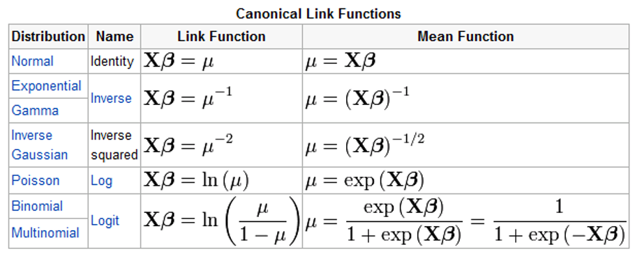

Commonly used link functions

## Binomial GLM for binary data (Bernoulli GLM/logistic regression/logistic GLM)

A logistic regression model allows us to establish a relationship between a binary (0 vs. 1) outcome variable and a group of predictor variables. It models the logit-transformed probability of a certain outcome as a linear relationship with the predictor variables.

To demonstrate how linear regression model works, we will use the following study:

Bolger et al. (1997) investigated the impacts of habitat fragmentation on the occurrence of native rodents. [Quinn and Keough (2002)](https://www2.ib.unicamp.br/profs/fsantos/apostilas/Quinn%20&%20Keough.pdf) subsequently modeled the presence/absence native rodents against some Bolger et al. (1997) biogeographic variables.

Bolger et al. (1997) studied whether small fragments of the shrub habitats in canyons of San Diego, CA, isolated by urbanization, were capable of supporting viable populations of native rodent species.

The data set consists of rodent presence/absence and three predictor variables: 1. PERSHRUB = percentage of shrub cover 2. DISTX = the distance to the nearest large (>100 ha) “source canyon.” 3. AGE = time elapsed since the fragment was isolated by development

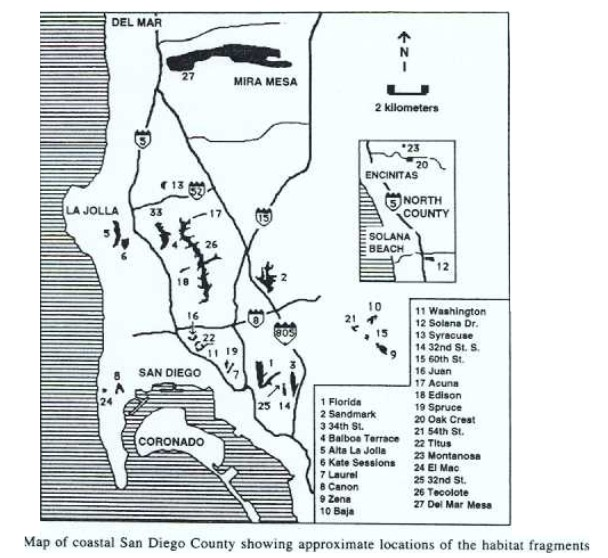

For this demonstration we need to install and load a new package.

```r
#install.packages("usdm") #Install package if it is not installed in your computer.
library(usdm)
```

### Import data set

Import the data set suing the ‘read.table’ function. The data for this example is in a .txt format. `Read.table` will read the .txt file and load it as a data frame into the **R** environment.

Look at the first lines of data using the `head` function.

```r
bolger <- read.table("Data/bolger.txt", header=T, sep= "")
head(bolger)
```

```
##   PERSHRUB DISTX AGE RODENTSP
## 1       66  2100  50        1
## 2       90   914  20        1
## 3       75  1676  34        1
## 4       75   243  34        1
## 5       60   822  16        1
## 6       50   121  14        1
```

> Note: It is often best to rescale continuous covariates to improve numerical stability in the models. We will skip this step for this example, but we will look into scaling in other examples.

### Investigate potential (multi)collinearity

When we fit a model we assume that the estimated effects of predictor variables are independent of each other. Thus, before we fit a model we first need to check our independent variables for potential collinearity.

Collinearity occurs when 2 or more independent variables have a strong linear relationship, making it difficult to determine which of the two collinear variables are more strongly associated with the response variable. Collinearity affects parameter estimates and increases both standard errors and p-values of parameters, likely obscuring some important relationships.

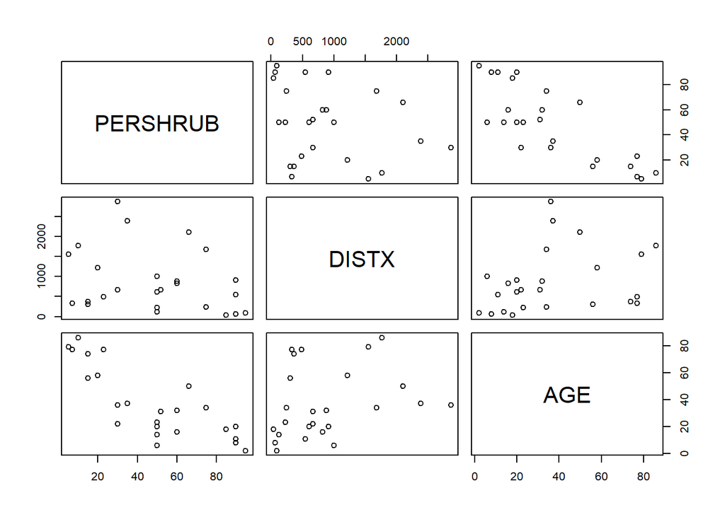

```r
plot(bolger[,1:3])
```

To make sure we do not have a (multi)collinearity problem in our predictor variables, we can look at the Variance Inflation Factor (VIF) for each covariate. Variance inflation is a measure of the degree of collinearity between variables. Any variables with a VIF value > to 3 (or 5 or 10 depending who you ask) are the cause of concerning collinearity in the model. If a covariate has a VIF > 3, remove it (or other correlated variables) and recalculate VIF after deletion.

```r
vifstep(bolger[,1:3])
```

```
## No variable from the 3 input variables has collinearity problem.
##
## The linear correlation coefficients ranges between:
## min correlation ( DISTX ~ PERSHRUB ):  -0.2745893
## max correlation ( AGE ~ PERSHRUB ):  -0.7952976
##
## ---------- VIFs of the remained variables --------
##   Variables      VIF
## 1  PERSHRUB 2.743579
## 2     DISTX 1.093362
## 3       AGE 2.750798
```

In our example there is no evidence of collinearity as all VIFs are < 3. Good!

### Fit a Binomial GLM

```r
bolger.glm <- glm(RODENTSP ~ DISTX + AGE + PERSHRUB,
                family=binomial (link= "logit"),
                data=bolger)
summary(bolger.glm)
```

```
##
## Call:
## glm(formula = RODENTSP ~ DISTX + AGE + PERSHRUB, family = binomial(link = "logit"),
##     data = bolger)
##
## Deviance Residuals:
##     Min       1Q   Median       3Q      Max
## -1.5823  -0.5985  -0.2813   0.3699   2.1702
##
## Coefficients:
##               Estimate Std. Error z value Pr(>|z|)
## (Intercept) -5.9099159  3.1125426  -1.899   0.0576 .
## DISTX        0.0003087  0.0007741   0.399   0.6900
## AGE          0.0250077  0.0376618   0.664   0.5067
## PERSHRUB     0.0958695  0.0406119   2.361   0.0182 *
## ---
## Signif. codes:  0 '***' 0.001 '**' 0.01 '*' 0.05 '.' 0.1 ' ' 1
##
## (Dispersion parameter for binomial family taken to be 1)
##
##     Null deviance: 34.617  on 24  degrees of freedom
## Residual deviance: 19.358  on 21  degrees of freedom
## AIC: 27.358
##
## Number of Fisher Scoring iterations: 5
```

### Model assumptions validation

Usually in a linear model we would use ‘plot(model1)’ to check the standardized residuals for any “patterns”. For binomial data, however, you will just see two bands in the residuals (this is simply a consequence of the binomial nature of the dependent variable).

We need to check for:

1. Evidence of model fit. Extract the **deviance residuals** and examine their distribution. Observations with a deviance residual > 2 may indicate a lack of fit.

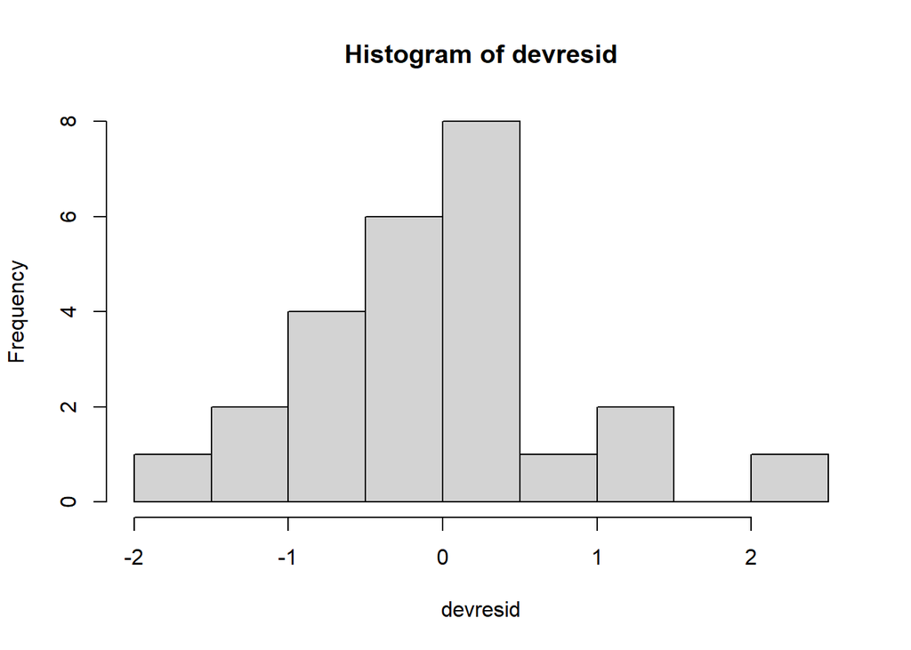

```r
devresid<-resid(bolger.glm, type = "deviance")
hist(devresid)
```

We can conclude there is no strong evidence of lack of fit. We can now feel confident about our model to make interpretations.

Let’s look again at the model summary:

```r
summary(bolger.glm)
```

```
##
## Call:
## glm(formula = RODENTSP ~ DISTX + AGE + PERSHRUB, family = binomial(link = "logit"),
##     data = bolger)
##
## Deviance Residuals:
##     Min       1Q   Median       3Q      Max
## -1.5823  -0.5985  -0.2813   0.3699   2.1702
##
## Coefficients:
##               Estimate Std. Error z value Pr(>|z|)
## (Intercept) -5.9099159  3.1125426  -1.899   0.0576 .
## DISTX        0.0003087  0.0007741   0.399   0.6900
## AGE          0.0250077  0.0376618   0.664   0.5067
## PERSHRUB     0.0958695  0.0406119   2.361   0.0182 *
## ---
## Signif. codes:  0 '***' 0.001 '**' 0.01 '*' 0.05 '.' 0.1 ' ' 1
##
## (Dispersion parameter for binomial family taken to be 1)
##
##     Null deviance: 34.617  on 24  degrees of freedom
## Residual deviance: 19.358  on 21  degrees of freedom
## AIC: 27.358
##
## Number of Fisher Scoring iterations: 5
```

The chance of native rodent occurrence increases significantly with increasing shrub cover ($B=0.096$, $p = 0.0182$). Neither fragment isolation age or distance had significant effects.

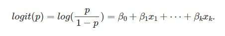

The default results are on the logit scale. The coefficient of PERSHRUB is: 0.096, so that a one unit change in percentage of shrub cover produces approximately a 0.096 unit change in the log odds of presence (i.e. a 0.096 unit change on the logit scale).

> The odds of presence are defined as the ratio of the probability of presence over the probability of absence. For instance, if the probability of presence is 0.8 and the probability of absence is 0.2, the odd ratios is 0.8/0.2=4, or the odds of presence are 4 to 1. For more information on how to interpret odds visit: https://stats.idre.ucla.edu/other/mult-pkg/faq/general/faq-how-do-i-interpret-odds-ratios-in-logistic-regression/

It is hard to think in terms of logits. We can plot the association between the probability of native rodent presence and percentage shrub cover.

See how the code for this plot has gotten much longer and more complex. Make sure you understand each line of code. Remember to use the `help` command when you do not understand a specific function and all its arguments.

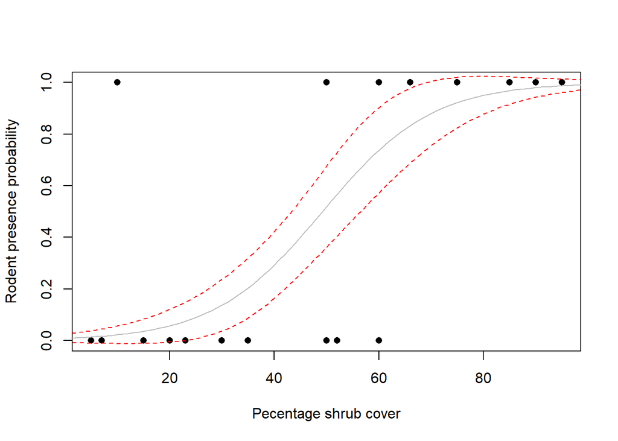

```r
xs <- seq(0, 100, 1)
bolger.predict <- predict(bolger.glm, type="response", se=T,
                          newdata=data.frame(DISTX=mean(bolger$DISTX), AGE=mean(bolger$AGE), PERSHRUB=xs))

# Plot results
plot(bolger$RODENTSP ~ bolger$PERSHRUB, xlab="Pecentage shrub cover", ylab="Rodent presence probability", axes=T, pch=16)
lines(bolger.predict$fit~xs, type="l", col="gray")
lines(bolger.predict$fit + bolger.predict$se.fit~xs, col="red", type= "l", lty=2)
lines(bolger.predict$fit - bolger.predict$se.fit~xs, col="red", type= "l", lty=2)
```

***

What is the probability of native rodent occurrence with a shrub cover of 80%, distanceX of 100, and fragment isolation age of 5.

```r
predict(bolger.glm, type="response", se=T, newdata=data.frame(DISTX=100, AGE=5, PERSHRUB=80))
```

```
## $fit
##         1
## 0.8716415
##
## $se.fit
##         1
## 0.1277815
##
## $residual.scale
## [1] 1
```

Note that the predict function already converts values from the logit scale back to the probability scale.

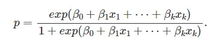

To do that manually, we can do the following:

```r
x <- -5.9099159 + 0.0003087*100 + 0.0250077 * 5 + 0.0958695 * 80
exp(x)/(exp(x)+1) # This is the inverse of the logit scale
```

```
## [1] 0.8716417
```

```r
plogis(x) # Use a built in function
```

```
## [1] 0.8716417
```